# Vancouver Crime Data Analysis and Visualization

```python
import numpy as np
import pandas as pd
import matplotlib.pyplot as plt
```

### Vancouver Crime Data

```python
cd = pd.read_csv('crimedata_csv_AllNeighbourhoods_2023.csv')
cd
```

|  | TYPE | YEAR | MONTH | DAY | HOUR | MINUTE | HUNDRED_BLOCK | NEIGHBOURHOOD | X | Y |
| --- | --- | --- | --- | --- | --- | --- | --- | --- | --- | --- |
| 0 | Break and Enter Commercial | 2023 | 4 | 1 | 4 | 7 | 10XX BEACH AVE | West End | 490197.8719 | 5.458239e+06 |
| 1 | Break and Enter Commercial | 2023 | 4 | 3 | 0 | 50 | 10XX BEACH AVE | Central Business District | 490249.2307 | 5.458167e+06 |
| 2 | Break and Enter Commercial | 2023 | 5 | 11 | 18 | 0 | 10XX BEACH AVE | Central Business District | 490249.2307 | 5.458167e+06 |
| 3 | Break and Enter Commercial | 2023 | 8 | 9 | 4 | 31 | 10XX BEACH AVE | Central Business District | 490268.4320 | 5.458143e+06 |
| 4 | Break and Enter Commercial | 2023 | 9 | 2 | 4 | 24 | 10XX BIDWELL ST | West End | 489996.5444 | 5.459475e+06 |
| ... | ... | ... | ... | ... | ... | ... | ... | ... | ... | ... |
| 26538 | Vehicle Collision or Pedestrian Struck (with I... | 2023 | 5 | 4 | 16 | 0 | X BLOCK W 49TH AVE | Oakridge | 492266.0000 | 5.452558e+06 |
| 26539 | Vehicle Collision or Pedestrian Struck (with I... | 2023 | 5 | 11 | 16 | 19 | YORK AVE / ARBUTUS ST | Kitsilano | 488896.0000 | 5.457665e+06 |
| 26540 | Vehicle Collision or Pedestrian Struck (with I... | 2023 | 9 | 18 | 8 | 16 | YORK AVE / YEW ST | Kitsilano | 488723.0000 | 5.457670e+06 |
| 26541 | Vehicle Collision or Pedestrian Struck (with I... | 2023 | 6 | 15 | 11 | 35 | YUKON ST / W 8TH AVE | Mount Pleasant | 491787.0000 | 5.456800e+06 |
| 26542 | Vehicle Collision or Pedestrian Struck (with I... | 2023 | 2 | 22 | 12 | 12 | YUKON ST / W BROADWAY AVE | Mount Pleasant | 491786.0000 | 5.456719e+06 |

26543 rows × 10 columns

This data describes all the crimes that were reported to the Vancouver Police Department in 2023. Each row is a crime reported and contains the time, location and type of crime which means that there were 26,543 crimes documented in the above data frame.

### Crimes on January 25th 2023

```python
j25cd = cd.query('YEAR == 2023 & MONTH == 1 & DAY == 25')
j25cd
```

|  | TYPE | YEAR | MONTH | DAY | HOUR | MINUTE | HUNDRED_BLOCK | NEIGHBOURHOOD | X | Y |
| --- | --- | --- | --- | --- | --- | --- | --- | --- | --- | --- |
| 76 | Break and Enter Commercial | 2023 | 1 | 25 | 3 | 45 | 11XX COMMERCIAL DR | Grandview-Woodland | 494945.3438 | 5.457962e+06 |
| 142 | Break and Enter Commercial | 2023 | 1 | 25 | 3 | 30 | 12XX BUTE ST | West End | 490291.7177 | 5.458789e+06 |
| 152 | Break and Enter Commercial | 2023 | 1 | 25 | 4 | 49 | 12XX GRANVILLE ST | Central Business District | 490711.4545 | 5.458168e+06 |
| 806 | Break and Enter Commercial | 2023 | 1 | 25 | 10 | 42 | 3XX SW MARINE DR | Marpole | 491652.5825 | 5.450915e+06 |
| 828 | Break and Enter Commercial | 2023 | 1 | 25 | 0 | 15 | 3XX WATER ST | Central Business District | 492018.5925 | 5.459083e+06 |
| ... | ... | ... | ... | ... | ... | ... | ... | ... | ... | ... |
| 24727 | Theft of Bicycle | 2023 | 1 | 25 | 5 | 0 | 25XX E 27TH AVE | Renfrew-Collingwood | 496059.2338 | 5.454838e+06 |
| 25188 | Theft of Bicycle | 2023 | 1 | 25 | 22 | 30 | SEYMOUR ST / W CORDOVA ST | Central Business District | 491865.6971 | 5.459181e+06 |
| 25632 | Theft of Vehicle | 2023 | 1 | 25 | 22 | 0 | 64XX BUTLER ST | Killarney | 497549.2137 | 5.452528e+06 |
| 25681 | Theft of Vehicle | 2023 | 1 | 25 | 4 | 39 | 7XX E 14TH AVE | Mount Pleasant | 493510.2494 | 5.456130e+06 |
| 26278 | Vehicle Collision or Pedestrian Struck (with I... | 2023 | 1 | 25 | 9 | 19 | MAIN ST / E 17TH AVE | Riley Park | 492630.0000 | 5.455884e+06 |

90 rows × 10 columns

### FIGURE:

```python
j25cdtypes = j25cd.groupby('TYPE').size().reset_index(name='COUNT')
j25cdtypes
```

|  | TYPE | COUNT |
| --- | --- | --- |
| 0 | Break and Enter Commercial | 7 |
| 1 | Mischief | 14 |
| 2 | Offence Against a Person | 12 |
| 3 | Other Theft | 26 |
| 4 | Theft from Vehicle | 26 |
| 5 | Theft of Bicycle | 2 |
| 6 | Theft of Vehicle | 2 |
| 7 | Vehicle Collision or Pedestrian Struck (with I... | 1 |

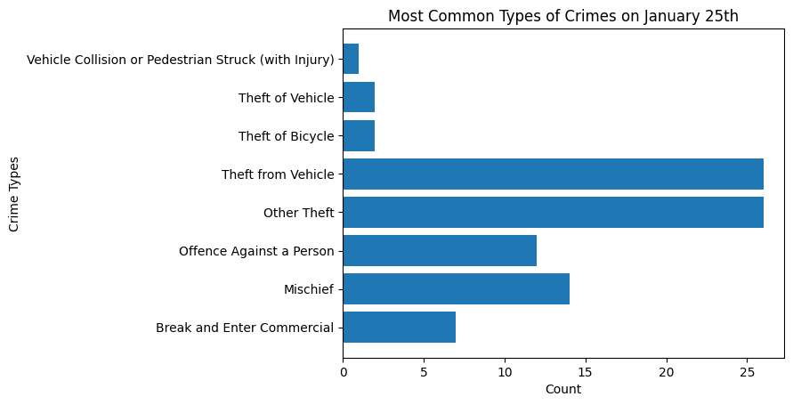

```python
fig, ax = plt.subplots()
ax.barh(j25cdtypes['TYPE'], j25cdtypes['COUNT'])
ax.set_title('Most Common Types of Crimes on January 25th')
ax.set_xlabel('Count')
ax.set_ylabel('Crime Types')
plt.show()
```

The most common crime reported on my birthday was "Theft from Vehicle" and "Other Theft". The least common was "Vehicle Collision or Pedestrian Struck (with injury)". Theft could be most common due to it being comparatively low risk without much punishment if caught and low probability of being caught. And vehicle collision being the least common could be because people are generally good drivers.